# Tornadoes are Greatest Risk to Public Health While Flooding Carries the Highest Economic Risk

Patrick J. O’Malley

August 8, 2017

## Synopsis

The purpose of this anlaysis is to determine which storm events in the US are most harmful with respect both to population health and economically. The initial hypothesis is that smaller but more intense events like tornadoes will have more effects on health, while larger events like hurricanes will have a greater economic effect. The data used to investigate this subject comes from the NOAA Storm Database, and contains events from the years 1950-2011. These data show that for both health and economic effects, the storm events that do the highest average damage (heat and hurricanes respectively) are overshadowed by events that have much higher number of occurances (tornadoes and floods) when looking at total damage.

## Data Processing

Begin by downloading the raw .csv file from its source on the internet

```r
url <- "https://d396qusza40orc.cloudfront.net/repdata%2Fdata%2FStormData.csv.bz2"
download.file(url, "stormdata.csv.bz2")
```

Load the data into R

```r
storm <- read.csv("stormdata.csv.bz2")
```

View summaries of the data

```r
dim(storm) # 902,297 x 37
```

```
## [1] 902297     37
```

```r
str(storm)
```

```
## 'data.frame':    902297 obs. of  37 variables:
##  $ STATE__   : num  1 1 1 1 1 1 1 1 1 1 ...
##  $ BGN_DATE  : Factor w/ 16335 levels "1/1/1966 0:00:00",..: 6523 6523 4242 11116 2224 2224 2260 383 3980 3980 ...
##  $ BGN_TIME  : Factor w/ 3608 levels "00:00:00 AM",..: 272 287 2705 1683 2584 3186 242 1683 3186 3186 ...
##  $ TIME_ZONE : Factor w/ 22 levels "ADT","AKS","AST",..: 7 7 7 7 7 7 7 7 7 7 ...
##  $ COUNTY    : num  97 3 57 89 43 77 9 123 125 57 ...
##  $ COUNTYNAME: Factor w/ 29601 levels "","5NM E OF MACKINAC BRIDGE TO PRESQUE ISLE LT MI",..: 13513 1873 4598 10592 4372 10094 1973 23873 24418 4598 ...
##  $ STATE     : Factor w/ 72 levels "AK","AL","AM",..: 2 2 2 2 2 2 2 2 2 2 ...
##  $ EVTYPE    : Factor w/ 985 levels "   HIGH SURF ADVISORY",..: 834 834 834 834 834 834 834 834 834 834 ...
##  $ BGN_RANGE : num  0 0 0 0 0 0 0 0 0 0 ...
##  $ BGN_AZI   : Factor w/ 35 levels "","  N"," NW",..: 1 1 1 1 1 1 1 1 1 1 ...
##  $ BGN_LOCATI: Factor w/ 54429 levels "","- 1 N Albion",..: 1 1 1 1 1 1 1 1 1 1 ...
##  $ END_DATE  : Factor w/ 6663 levels "","1/1/1993 0:00:00",..: 1 1 1 1 1 1 1 1 1 1 ...
##  $ END_TIME  : Factor w/ 3647 levels ""," 0900CST",..: 1 1 1 1 1 1 1 1 1 1 ...
##  $ COUNTY_END: num  0 0 0 0 0 0 0 0 0 0 ...
```

[output cut: 23 more lines]

The date column is loaded as a factor so it will be converted to a date object to allow calculations

```r
library(lubridate)
storm$BGN_DATE <- as.character(storm$BGN_DATE)
storm$BGN_DATE <- mdy_hms(storm$BGN_DATE)
class(storm$BGN_DATE)
```

```
## [1] "POSIXct" "POSIXt"
```

Many events are split into serveral categories and should be combined into a single event category to get an accurate account of its overall effects.

```r
library(dplyr)
# create new variable to store combined events
storm$EVTYPE_comb <- storm$EVTYPE
# all heat related events shoul be combined
evt_heat <- droplevels(unique(storm$EVTYPE_comb[grepl("HEAT", storm$EVTYPE_comb)]))
table(droplevels(storm$EVTYPE[which(storm$EVTYPE %in% evt_heat)]))
```

```
##
## DROUGHT/EXCESSIVE HEAT         EXCESSIVE HEAT EXCESSIVE HEAT/DROUGHT
##                     13                   1678                      1
##           EXTREME HEAT                   HEAT           HEAT DROUGHT
##                     22                    767                      1
##              HEAT WAVE      HEAT WAVE DROUGHT             HEAT WAVES
##                     74                      1                      2
##           HEAT/DROUGHT            RECORD HEAT       RECORD HEAT WAVE
##                      1                     81                      1
##  RECORD/EXCESSIVE HEAT
##                      3
```

```r
storm$EVTYPE_comb[which(storm$EVTYPE_comb %in% evt_heat)] <- "HEAT"
table(droplevels(storm$EVTYPE_comb[grepl("HEAT", storm$EVTYPE_comb)]))
```

```
##
## HEAT
## 2645
```

```r
# combine other events
# hurricane
evt_hurr <- droplevels(unique(storm$EVTYPE_comb[grepl("HURRICANE", storm$EVTYPE_comb)]))
evt_hurr
```

```
## [1] HURRICANE OPAL/HIGH WINDS  HURRICANE ERIN
## [3] HURRICANE OPAL             HURRICANE
## [5] HURRICANE-GENERATED SWELLS HURRICANE EMILY
## [7] HURRICANE GORDON           HURRICANE FELIX
## [9] HURRICANE/TYPHOON
## 9 Levels: HURRICANE HURRICANE-GENERATED SWELLS ... HURRICANE/TYPHOON
```

```r
storm$EVTYPE_comb[which(storm$EVTYPE_comb %in% evt_hurr)] <- "HURRICANE"
table(droplevels(storm$EVTYPE_comb[grepl("HURRICANE", storm$EVTYPE_comb)]))
```

```
##
## HURRICANE
##       286
```

```r
# flood
evt_flood <- droplevels(unique(storm$EVTYPE_comb[grepl("FLOOD|FLD", storm$EVTYPE_comb)]))
evt_flood
```

```
##   [1] ICE STORM/FLASH FLOOD          FLASH FLOOD
##   [3] FLASH FLOODING                 FLOODING
##   [5] FLOOD                          FLASH FLOODING/THUNDERSTORM WI
##   [7] BREAKUP FLOODING               RIVER FLOOD
##   [9] COASTAL FLOOD                  FLOOD WATCH/
##  [11] FLASH FLOODS                   FLOODING/HEAVY RAIN
##  [13] HEAVY SURF COASTAL FLOODING    URBAN FLOODING
##  [15] URBAN/SMALL FLOODING           LOCAL FLOOD
##  [17] FLOOD/FLASH FLOOD              FLOOD/RAIN/WINDS
##  [19] FLASH FLOOD WINDS              URBAN/SMALL STREAM FLOODING
##  [21] STREAM FLOODING                FLASH FLOOD/
##  [23] FLOOD/RAIN/WIND                SMALL STREAM URBAN FLOOD
##  [25] URBAN FLOOD                    HEAVY RAIN/FLOODING
##  [27] COASTAL FLOODING               HIGH WINDS/FLOODING
##  [29] URBAN/SMALL STREAM FLOOD       MINOR FLOODING
```

[output cut: 37 more lines]

```r
storm$EVTYPE_comb[which(storm$EVTYPE_comb %in% evt_flood)] <- "FLOOD"
table(droplevels(storm$EVTYPE_comb[grepl("FLOOD", storm$EVTYPE_comb)]))
```

```
##
## FLOOD
## 86059
```

```r
# wildfire
evt_fire <- droplevels(unique(storm$EVTYPE_comb[grepl("[Ff][Ii][Rr][Ee]", storm$EVTYPE_comb)]))
evt_fire
```

```
##  [1] WILD FIRES        WILDFIRE          WILD/FOREST FIRE
##  [4] GRASS FIRES       LIGHTNING FIRE    FOREST FIRES
##  [7] WILDFIRES         WILD/FOREST FIRES BRUSH FIRES
## [10] BRUSH FIRE        RED FLAG FIRE WX
## 11 Levels: BRUSH FIRE BRUSH FIRES FOREST FIRES ... WILDFIRES
```

```r
storm$EVTYPE_comb[which(storm$EVTYPE_comb %in% evt_fire)] <- "WILDFIRE"
table(droplevels(storm$EVTYPE_comb[grepl("WILDFIRE", storm$EVTYPE_comb)]))
```

```
##
## WILDFIRE
##     4240
```

```r
# thunderstorm
evt_thunderstorm <- droplevels(unique(storm$EVTYPE_comb[grepl("THUNDERSTORM", storm$EVTYPE_comb)]))
evt_thunderstorm
```

```
##  [1] THUNDERSTORM WINDS             THUNDERSTORM WIND
##  [3] THUNDERSTORM WINS              THUNDERSTORM WINDS LIGHTNING
##  [5] THUNDERSTORM WINDS/HAIL        THUNDERSTORM WINDS HAIL
##  [7] THUNDERSTORM                   THUNDERSTORM WINDS/FUNNEL CLOU
##  [9] SEVERE THUNDERSTORM            SEVERE THUNDERSTORMS
## [11] SEVERE THUNDERSTORM WINDS      THUNDERSTORMS WINDS
## [13] THUNDERSTORMS                  LIGHTNING THUNDERSTORM WINDSS
## [15] THUNDERSTORM WINDS 60          THUNDERSTORM WINDSS
## [17] LIGHTNING THUNDERSTORM WINDS   LIGHTNING AND THUNDERSTORM WIN
## [19] THUNDERSTORM WINDS53           THUNDERSTORM WINDS 13
## [21] THUNDERSTORM WINDS SMALL STREA THUNDERSTORM WINDS 2
## [23] THUNDERSTORM WINDS 61          THUNDERSTORM DAMAGE
## [25] THUNDERSTORMW 50               THUNDERSTORMS WIND
## [27] THUNDERSTORM  WINDS            THUNDERSTORM WINDS/ HAIL
## [29] THUNDERSTORM WIND/LIGHTNING    THUNDERSTORM WIND G50
```

[output cut: 24 more lines]

```r
storm$EVTYPE_comb[which(storm$EVTYPE_comb %in% evt_thunderstorm)] <- "THUNDERSTORM"
table(droplevels(storm$EVTYPE_comb[grepl("THUNDERSTORM", storm$EVTYPE_comb)]))
```

```
##
## THUNDERSTORM
##       109565
```

```r
# wind
evt_wind <- droplevels(unique(storm$EVTYPE_comb[grepl("WIND", storm$EVTYPE_comb)]))
evt_wind
```

```
##   [1] TSTM WIND                      HIGH WINDS
##   [3] WIND                           HIGH WIND
##   [5] WIND CHILL                     HIGH WIND/BLIZZARD
##   [7] HIGH WIND AND HIGH TIDES       HIGH WIND/BLIZZARD/FREEZING RA
##   [9] HIGH WIND AND HEAVY SNOW       RECORD COLD AND HIGH WIND
##  [11] HIGH WINDS HEAVY RAINS         HIGH WIND/ BLIZZARD
##  [13] BLIZZARD/HIGH WIND             HIGH WIND/LOW WIND CHILL
##  [15] HIGH WINDS AND WIND CHILL      HEAVY SNOW/HIGH WINDS/FREEZING
##  [17] WIND CHILL/HIGH WIND           HIGH WIND/WIND CHILL/BLIZZARD
##  [19] HIGH WIND/WIND CHILL           HIGH WIND/HEAVY SNOW
##  [21] HIGH WIND/SEAS                 HIGH WINDS/HEAVY RAIN
##  [23] HEAVY SNOW/WIND                WIND DAMAGE
##  [25] WINTER STORM/HIGH WIND         WINTER STORM/HIGH WINDS
##  [27] GUSTY WINDS                    STRONG WINDS
##  [29] SNOW AND WIND                  HIGH WINDS DUST STORM
```

[output cut: 56 more lines]

```r
storm$EVTYPE_comb[which(storm$EVTYPE_comb %in% evt_wind)] <- "WIND"
table(droplevels(storm$EVTYPE_comb[grepl("WIND", storm$EVTYPE_comb)]))
```

```
##
##   WIND
## 255358
```

```r
# snow
evt_snow <- droplevels(unique(storm$EVTYPE_comb[grepl("[Ss][Nn][Oo][Ww]", storm$EVTYPE_comb)]))
evt_snow
```

```
##   [1] SNOW                          SNOW/ICE
##   [3] HEAVY SNOW                    HEAVY SNOW/HIGH
##   [5] RECORD SNOWFALL               HEAVY SNOWPACK
##   [7] BLIZZARD/HEAVY SNOW           BLOWING SNOW
##   [9] LIGHT SNOW AND SLEET          FIRST SNOW
##  [11] SLEET/RAIN/SNOW               RAIN/SNOW
##  [13] SNOW/RAIN/SLEET               FREEZING RAIN/SNOW
##  [15] THUNDERSNOW                   HEAVY RAIN/SNOW
##  [17] SNOW/SLEET/FREEZING RAIN      EARLY SNOW
##  [19] HEAVY SNOW/BLOWING SNOW       SNOW AND HEAVY SNOW
##  [21] SNOW/HEAVY SNOW               ICE/SNOW
##  [23] HEAVY SNOW/BLIZZARD           SNOW AND ICE
##  [25] SNOWSTORM                     SNOW AND ICE STORM
##  [27] HEAVY SNOW/SLEET              HEAVY SNOW/ICE STORM
##  [29] HEAVY SNOW AND ICE STORM      SNOW/RAIN
```

[output cut: 44 more lines]

```r
storm$EVTYPE_comb[which(storm$EVTYPE_comb %in% evt_snow)] <- "SNOW"
table(droplevels(storm$EVTYPE_comb[grepl("SNOW", storm$EVTYPE_comb)]))
```

```
##
##  SNOW
## 17677
```

```r
# hail
evt_hail <- droplevels(unique(storm$EVTYPE_comb[grepl("[Hh][Aa][Ii][Ll]", storm$EVTYPE_comb)]))
evt_hail
```

```
##  [1] HAIL              HAIL 1.75)        HAIL STORM
##  [4] HAIL 75           SMALL HAIL        HAIL 80
##  [7] FUNNEL CLOUD/HAIL HAIL 0.75         HAIL 1.00
## [10] HAIL 1.75         HAIL 225          HAIL 0.88
## [13] DEEP HAIL         HAIL 88           HAIL 175
## [16] HAIL 100          HAIL 150          HAIL 075
## [19] HAIL 125          HAIL 200          HAIL DAMAGE
## [22] HAIL 088          HAIL/ICY ROADS    HAIL ALOFT
## [25] HAIL 275          HAIL 450          HAILSTORM
## [28] HAILSTORMS        small hail        Hail(0.75)
## [31] Small Hail        LATE SEASON HAIL  NON SEVERE HAIL
## [34] MARINE HAIL
## 34 Levels: DEEP HAIL FUNNEL CLOUD/HAIL HAIL HAIL 0.75 ... SMALL HAIL
```

```r
storm$EVTYPE_comb[which(storm$EVTYPE_comb %in% evt_hail)] <- "HAIL"
table(droplevels(storm$EVTYPE_comb[grepl("HAIL", storm$EVTYPE_comb)]))
```

```
##
##   HAIL
## 289275
```

```r
# rip current
evt_rip <- droplevels(unique(storm$EVTYPE_comb[grepl("[Rr][Ii][Pp]", storm$EVTYPE_comb)]))
evt_rip
```

```
## [1] RIP CURRENT             RIP CURRENTS HEAVY SURF RIP CURRENTS/HEAVY SURF
## [4] RIP CURRENTS
## 4 Levels: RIP CURRENT RIP CURRENTS ... RIP CURRENTS/HEAVY SURF
```

```r
storm$EVTYPE_comb[which(storm$EVTYPE_comb %in% evt_rip)] <- "RIP CURRENT"
table(droplevels(storm$EVTYPE_comb[grepl("RIP CURRENT", storm$EVTYPE_comb)]))
```

```
##
## RIP CURRENT
##         777
```

```r
# winter storm
evt_winter <- droplevels(unique(storm$EVTYPE_comb[grepl("[Ww][Ii][Nn][Tt][Ee][Rr]|ICE|BLIZZARD|SNOW", storm$EVTYPE_comb)]))
evt_winter
```

```
##  [1] SNOW                   WINTER STORM           BLIZZARD
##  [4] BLIZZARD WEATHER       ICE STORM              WINTER STORMS
##  [7] ICE                    WINTER WEATHER         GLAZE ICE
## [10] SLEET/ICE STORM        GROUND BLIZZARD        ICE FLOES
## [13] BLIZZARD/FREEZING RAIN GLAZE/ICE STORM        BLIZZARD/WINTER STORM
## [16] ICE JAM                WINTER MIX             Winter Weather
## [19] BLACK ICE              WINTERY MIX            ICE PELLETS
## [22] ICE ROADS              WINTER WEATHER MIX     PATCHY ICE
## [25] WINTER WEATHER/MIX     ICE ON ROAD
## 26 Levels: BLACK ICE BLIZZARD BLIZZARD WEATHER ... WINTERY MIX
```

```r
storm$EVTYPE_comb[which(storm$EVTYPE_comb %in% evt_winter)] <- "WINTER STORM"
table(droplevels(storm$EVTYPE_comb[grepl("WINTER STORM", storm$EVTYPE_comb)]))
```

```
##
## WINTER STORM
##        42092
```

```r
# tornado
evt_tornado <- droplevels(unique(storm$EVTYPE_comb[grepl("[Ff][Uu][Nn][Nn][Ee][Ll]|TORNADO", storm$EVTYPE_comb)]))
evt_tornado
```

```
##  [1] TORNADO                 FUNNEL CLOUD
##  [3] TORNADO F0              FUNNEL
##  [5] WALL CLOUD/FUNNEL CLOUD FUNNEL CLOUDS
##  [7] TORNADOS                WATERSPOUT/TORNADO
##  [9] WATERSPOUT TORNADO      WATERSPOUT-TORNADO
## [11] COLD AIR FUNNEL         COLD AIR FUNNELS
## [13] COLD AIR TORNADO        WATERSPOUT/ TORNADO
## [15] TORNADO F3              FUNNEL CLOUD.
## [17] TORNADO F1              TORNADO/WATERSPOUT
## [19] TORNADO F2              TORNADOES
## [21] FUNNELS                 WATERSPOUT FUNNEL CLOUD
## [23] Funnel Cloud            TORNADO DEBRIS
## 24 Levels: COLD AIR FUNNEL COLD AIR FUNNELS COLD AIR TORNADO ... WATERSPOUT/TORNADO
```

```r
storm$EVTYPE_comb[which(storm$EVTYPE_comb %in% evt_tornado)] <- "TORNADO"
table(droplevels(storm$EVTYPE_comb[grepl("TORNADO", storm$EVTYPE_comb)]))
```

```
##
## TORNADO
##   67686
```

```r
storm %>%
        group_by(EVTYPE_comb) %>%
        summarise(n = n()) %>%
        arrange(desc(n)) %>%
        slice(1:10)
```

```
## # A tibble: 10 x 2
##     EVTYPE_comb      n
##          <fctr>  <int>
##  1         HAIL 289275
##  2         WIND 255358
##  3 THUNDERSTORM 109565
##  4        FLOOD  86059
##  5      TORNADO  67686
##  6 WINTER STORM  42092
##  7    LIGHTNING  15754
##  8   HEAVY RAIN  11723
##  9     WILDFIRE   4240
## 10   WATERSPOUT   3796
```

## Results

### Population Health

View top events with respect to harm to population health. We are interested in the FATALITIES and INJURIES columns for determining an events affect on health. Here are tables of the two column’s values.

```r
# look at distributions of deaths and injuries

table(storm$FATALITIES)
```

```
##
##      0      1      2      3      4      5      6      7      8      9
## 895323   5010    996    314    166    114     71     53     33     30
##     10     11     12     13     14     15     16     17     18     19
##     30     24     12     13     12      5     11      7      2      2
##     20     21     22     23     24     25     26     27     29     30
##      7      3      6      3      4      5      1      3      3      3
##     31     32     33     34     36     37     38     42     44     46
##      3      3      3      1      1      1      1      3      1      1
##     49     50     57     67     74     75     90     99    114    116
##      1      1      2      1      1      1      1      1      1      1
##    158    583
##      1      1
```

```r
table(storm$INJURIES)
```

```
##
##      0      1      2      3      4      5      6      7      8      9
## 884693   7756   3134   1552    931    709    529    280    255    186
##     10     11     12     13     14     15     16     17     18     19
##    271    109    181     84     84    138     51     57     52     30
##     20     21     22     23     24     25     26     27     28     29
##    130     28     40     26     37     65     31     23     25     16
##     30     31     32     33     34     35     36     37     38     39
##     67     12     19     13     10     24     12     13     10      8
##     40     41     42     43     44     45     46     47     48     49
##     48      8     12      7      6     14      7     10      8      7
##     50     51     52     53     54     55     56     57     58     59
##     58      6      5      9      4     12      4      7      6      9
##     60     61     62     63     64     65     66     67     68     69
##     17      4      4      3      4     10      1      3      2      2
```

[output cut: 26 more lines]

The vast majority of events result in no deaths or injuries. Since we are interseted in events that are damaging to the population health, we will filter for events which resulted in a fatality. We also filter for events which have occured over 10 times as there are numerous one-off EVTYPE classes that have a very high average number of fatalities.

```r
library(dplyr)
# Across the United States, which types of events (as indicated in the EVTYPE variable) are most harmful with respect to population health?

fatal_storm <- filter(storm, FATALITIES > 0)
worst_events <- fatal_storm %>%
        group_by(EVTYPE_comb) %>%
        summarise(avg_deaths = mean(FATALITIES, na.rm = TRUE),
                  max_deaths = max(FATALITIES, na.rm = TRUE),
                  total_deaths = sum(FATALITIES, na.rm = TRUE),
                  avg_inj = mean(INJURIES, na.rm = TRUE),
                  max_inj = max(INJURIES, na.rm = TRUE),
                  total_inj = sum(INJURIES, na.rm = TRUE),
                  n = n()) %>%
        arrange(desc(avg_deaths)) %>%
        filter(n > 10) %>%
        slice(1:10)
worst_events
```

```
## # A tibble: 10 x 8
##             EVTYPE_comb avg_deaths max_deaths total_deaths    avg_inj
##                  <fctr>      <dbl>      <dbl>        <dbl>      <dbl>
##  1                 HEAT   3.947170        583         3138  8.1698113
##  2              TORNADO   3.515908        158         5636 37.5708047
##  3            LANDSLIDE   3.166667         14           38  2.2500000
##  4            HURRICANE   2.812500         15          135 25.7708333
##  5             WILDFIRE   2.368421         14           90 11.2368421
##  6       TROPICAL STORM   2.320000         22           58 10.9600000
##  7                  FOG   1.675676         11           62  8.3243243
##  8           HEAVY RAIN   1.580645         19           98  0.6612903
##  9         WINTER STORM   1.573892         14          639  8.7857143
## 10 HEAVY SURF/HIGH SURF   1.555556          5           42  0.3703704
## # ... with 3 more variables: max_inj <dbl>, total_inj <dbl>, n <int>
```

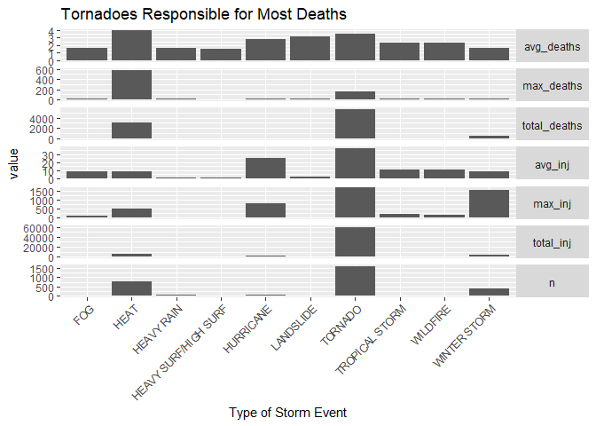

```r
library(reshape2)
library(ggplot2)
# melt data to enable a grid faceted plot for the different health outcomes
worst_melted <- melt(worst_events, id.vars = "EVTYPE_comb", variable.name = "health_outcome")
ggplot(data = worst_melted, aes(x = EVTYPE_comb, y = value)) + geom_col() +
        facet_grid(health_outcome~., scales = "free") +
        theme(axis.text.x = element_text(angle = 45, hjust = 1, vjust = 1),
              strip.text.y = element_text(angle = 0)) +
        ggtitle("Tornadoes Responsible for Most Deaths") +
        labs(xlab("Type of Storm Event"))
```

```r
tornado_deaths <- filter(worst_events, EVTYPE_comb == "TORNADO")
tornado_deaths
```

```
## # A tibble: 1 x 8
##   EVTYPE_comb avg_deaths max_deaths total_deaths avg_inj max_inj total_inj
##        <fctr>      <dbl>      <dbl>        <dbl>   <dbl>   <dbl>     <dbl>
## 1     TORNADO   3.515908        158         5636 37.5708    1700     60226
## # ... with 1 more variables: n <int>
```

```r
tornado_death_perc <- tornado_deaths$total_deaths / sum(storm$FATALITIES)
tornado_death_perc <- round(tornado_death_perc * 100, 2)
tornado_death_perc <- paste(tornado_death_perc, "%")
```

### Economic Consequences

View top events with respect to economic impact. We are interested in the PROPDMG and CROPDMG columns for determing an events economic effect. Both of these columns also have an accompanying modifier to signify thousands, millions etc. A new variable will be created to contain the actual dollar amount.

```r
summary(storm$PROPDMG)
```

```
##    Min. 1st Qu.  Median    Mean 3rd Qu.    Max.
##    0.00    0.00    0.00   12.06    0.50 5000.00
```

```r
levels(storm$PROPDMGEXP)
```

```
##  [1] ""  "-" "?" "+" "0" "1" "2" "3" "4" "5" "6" "7" "8" "B" "h" "H" "K"
## [18] "m" "M"
```

```r
table(storm$PROPDMGEXP)
```

```
##
##             -      ?      +      0      1      2      3      4      5
## 465934      1      8      5    216     25     13      4      4     28
##      6      7      8      B      h      H      K      m      M
##      4      5      1     40      1      6 424665      7  11330
```

```r
table(storm$CROPDMGEXP)
```

```
##
##             ?      0      2      B      k      K      m      M
## 618413      7     19      1      9     21 281832      1   1994
```

```r
storm %>%
        filter(PROPDMGEXP == "" & PROPDMG > 0) %>%
        slice(1:20)
```

```
## # A tibble: 20 x 38
##    STATE__   BGN_DATE BGN_TIME TIME_ZONE COUNTY  COUNTYNAME  STATE
##      <dbl>     <dttm>   <fctr>    <fctr>  <dbl>      <fctr> <fctr>
##  1       6 1995-03-09     0301       PST     41       MARIN     CA
##  2      12 1993-01-08     1130       EST    125       UNION     FL
##  3      13 1995-08-19     1700       EST     87     DECATUR     GA
##  4      13 1993-03-31     2015       EST    147        HART     GA
##  5      18 1993-05-12     1630       EST     17        CASS     IN
##  6      18 1995-05-14     0300       EST    163 VANDERBURGH     IN
##  7      18 1995-05-18     0215       CST     51      GIBSON     IN
##  8      18 1995-05-17     2220       CST     83        KNOX     IN
##  9      18 1995-05-28     2220       EST    137      RIPLEY     IN
## 10      20 1995-05-12     2048       CST     41   DICKINSON     KS
## 11      20 1995-04-08     1845       CST     43    DONIPHAN     KS
## 12      20 1995-04-08     1845       CST     43    DONIPHAN     KS
## 13      20 1995-05-23     0730       CST    177     SHAWNEE     KS
## 14      21 1995-05-24     2040       CST     47   CHRISTIAN     KY
## 15      21 1995-05-18     1112       CST     85     GRAYSON     KY
## 16      26 1995-04-18     2025       EST     45       EATON     MI
## 17      26 1993-04-24     1855       EST     69       IOSCO     MI
## 18      28 1995-03-07     1010       CST     49       HINDS     MS
## 19      28 1995-03-07     1015       CST    127     SIMPSON     MS
## 20      36 1995-07-15     0630       EST     27    DUTCHESS     NY
## # ... with 31 more variables: EVTYPE <fctr>, BGN_RANGE <dbl>,
## #   BGN_AZI <fctr>, BGN_LOCATI <fctr>, END_DATE <fctr>, END_TIME <fctr>,
## #   COUNTY_END <dbl>, COUNTYENDN <lgl>, END_RANGE <dbl>, END_AZI <fctr>,
## #   END_LOCATI <fctr>, LENGTH <dbl>, WIDTH <dbl>, F <int>, MAG <dbl>,
## #   FATALITIES <dbl>, INJURIES <dbl>, PROPDMG <dbl>, PROPDMGEXP <fctr>,
## #   CROPDMG <dbl>, CROPDMGEXP <fctr>, WFO <fctr>, STATEOFFIC <fctr>,
## #   ZONENAMES <fctr>, LATITUDE <dbl>, LONGITUDE <dbl>, LATITUDE_E <dbl>,
## #   LONGITUDE_ <dbl>, REMARKS <fctr>, REFNUM <dbl>, EVTYPE_comb <fctr>
```

```r
# most observations with property damage do have modifiers

storm %>%
        filter(CROPDMGEXP == "" & CROPDMG > 0) %>%
        slice(1:20)
```

```
## # A tibble: 3 x 38
##   STATE__   BGN_DATE BGN_TIME TIME_ZONE COUNTY COUNTYNAME  STATE
##     <dbl>     <dttm>   <fctr>    <fctr>  <dbl>     <fctr> <fctr>
## 1      38 1994-07-04     0400       CST     93   STUTSMAN     ND
## 2      48 1994-04-05     1700       CST    209       HAYS     TX
## 3      48 1994-04-15     1630       CST    325     MEDINA     TX
## # ... with 31 more variables: EVTYPE <fctr>, BGN_RANGE <dbl>,
## #   BGN_AZI <fctr>, BGN_LOCATI <fctr>, END_DATE <fctr>, END_TIME <fctr>,
## #   COUNTY_END <dbl>, COUNTYENDN <lgl>, END_RANGE <dbl>, END_AZI <fctr>,
## #   END_LOCATI <fctr>, LENGTH <dbl>, WIDTH <dbl>, F <int>, MAG <dbl>,
## #   FATALITIES <dbl>, INJURIES <dbl>, PROPDMG <dbl>, PROPDMGEXP <fctr>,
## #   CROPDMG <dbl>, CROPDMGEXP <fctr>, WFO <fctr>, STATEOFFIC <fctr>,
## #   ZONENAMES <fctr>, LATITUDE <dbl>, LONGITUDE <dbl>, LATITUDE_E <dbl>,
## #   LONGITUDE_ <dbl>, REMARKS <fctr>, REFNUM <dbl>, EVTYPE_comb <fctr>
```

```r
# most observations with crop damage do have modifiers
```

```r
# since we are interested in damaging storms we will filter for those that caused damage
damage_storm <- filter(storm, PROPDMG > 0 | CROPDMG > 0)
# initialize new columns
damage_storm$prop.damage.dollars <- 0
damage_storm$crop.damage.dollars <- 0

# use for loop to calculate dollar values
for (i in 1:length(damage_storm$STATE__)) {

        if (damage_storm$PROPDMGEXP[i] %in% c("k", "K")) {
                damage_storm$prop.damage.dollars[i] <-
                        damage_storm$PROPDMG[i] * 1000
        }
        else if (damage_storm$PROPDMGEXP[i] %in% c("m", "M")) {
                damage_storm$prop.damage.dollars[i] <-
                        damage_storm$PROPDMG[i] * 1000000
        }
        else if (damage_storm$PROPDMGEXP[i] %in% c("b", "B")) {
                damage_storm$prop.damage.dollars[i] <-
                        damage_storm$PROPDMG[i] * 1000000000
        }
        else {
                damage_storm$prop.damage.dollars[i] <- damage_storm$PROPDMG[i]
        }
}

for (i in 1:length(damage_storm$STATE__)) {

        if (damage_storm$CROPDMGEXP[i] %in% c("k", "K")) {
                damage_storm$crop.damage.dollars[i] <-
                        damage_storm$CROPDMG[i] * 1000
        }
        else if (damage_storm$CROPDMGEXP[i] %in% c("m", "M")) {
                damage_storm$crop.damage.dollars[i] <-
                        damage_storm$CROPDMG[i] * 1000000
        }
        else if (damage_storm$CROPDMGEXP[i] %in% c("b", "B")) {
                damage_storm$crop.damage.dollars[i] <-
                        damage_storm$CROPDMG[i] * 1000000000
        }
        else {
                damage_storm$crop.damage.dollars[i] <- damage_storm$CROPDMG[i]
        }
}
```

```r
# create a new data frame with total damage and event type
total_damage <- damage_storm %>%
        mutate(total.damage.dollars = prop.damage.dollars + crop.damage.dollars) %>%
        select(EVTYPE_comb, total.damage.dollars)
```

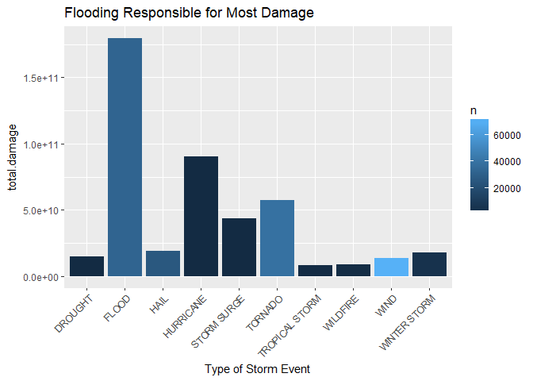

```r
plot_damage <- total_damage %>%
        group_by(EVTYPE_comb) %>%
        summarise(total.damage = sum(total.damage.dollars), n = n()) %>%
        arrange(desc(total.damage)) %>%
        slice(1:10)

ggplot(data = plot_damage, aes(x = EVTYPE_comb, y = total.damage, fill = n)) +
        geom_col() +
        theme(axis.text.x = element_text(angle = 45, hjust = 1, vjust = 1),
              strip.text.y = element_text(angle = 0)) +
        ggtitle("Flooding Responsible for Most Damage") +
        labs(xlab("Type of Storm Event"))
```

Floods are responsible for the most damage overall, however there are many more floods than hurricanes. We will also compare average damage per event.

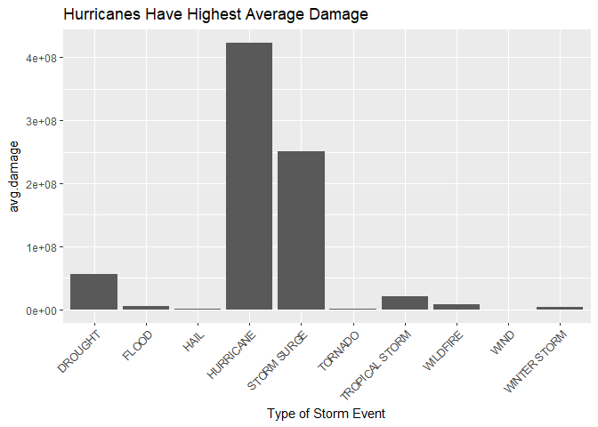

```r
# add average damage per events as a column
plot_damage <- mutate(plot_damage, avg.damage = total.damage / n)

ggplot(data = plot_damage, aes(x = EVTYPE_comb, y = avg.damage)) +
        geom_col() +
        theme(axis.text.x = element_text(angle = 45, hjust = 1, vjust = 1),
              strip.text.y = element_text(angle = 0)) +
        ggtitle("Hurricanes Have Highest Average Damage") +
        labs(xlab("Type of Storm Event"))
```

```r
avg_hurricane_dmg <- plot_damage[which(plot_damage$EVTYPE_comb == "HURRICANE"), 4]
avg_hurricane_dmg <- paste0("$", round(avg_hurricane_dmg / 1000000, 2), " Million")
```

When looking at average damage, hurricanes become the most significant storm event with $423.81 Million in damage per storm. Floods actaully do relatively little damage on average, so as with the health effects, it is the large number of them that makes them the most damaging event overall.